# Practical Machine Learning

Jo Hanna Lindsey Serato

December 11, 2018

### Introduction

This assignment aims to predict the manner in which the participants did the exercise. Random Forest, Data Tree Model, and GBM to train the input data. Random Forest turned out to have the most number of right predictions.

### Loading the datasets

The datasets were from the project: http://web.archive.org/web/20161224072740/http:/groupware.les.inf.puc-rio.br/har

```r
library(caret)
```

```r
library(rpart)
library(rpart.plot)
library(RColorBrewer)
library(rattle)
library(corrplot)
# set the URL for the download
urlTraining <- "http://d396qusza40orc.cloudfront.net/predmachlearn/pml-training.csv"
urlTesting  <- "http://d396qusza40orc.cloudfront.net/predmachlearn/pml-testing.csv"

# download the datasets
ds_training <- read.csv(url(urlTraining))
ds_testing  <- read.csv(url(urlTesting))
```

### Cleaning the data

Data that is not available and/or has features that is not included to the testing dataset is not included in the dataset that is used for training the models.

```r
features <- names(ds_testing[,colSums(is.na(ds_testing)) == 0])[8:59]
ds_training <- ds_training[,c(features,"classe")]
ds_testing <- ds_testing[,c(features,"problem_id")]

dim(ds_training)
```

```
## [1] 19622    53
```

```r
dim(ds_testing)
```

```
## [1] 20 53
```

### Separating the training and testing datasets

The training dataset is to to be 60% of the total cases as recommended in the course.

```r
set.seed(77777)

inTrain <- createDataPartition(ds_training$classe, p=0.6, list=FALSE)
training <- ds_training[inTrain,]
testing <- ds_training[-inTrain,]

dim(training);
```

```
## [1] 11776    53
```

```r
dim(testing)
```

```
## [1] 7846   53
```

### Correlation Analysis

The plot below shows that there are quite a few parameters that are correlated with each other.

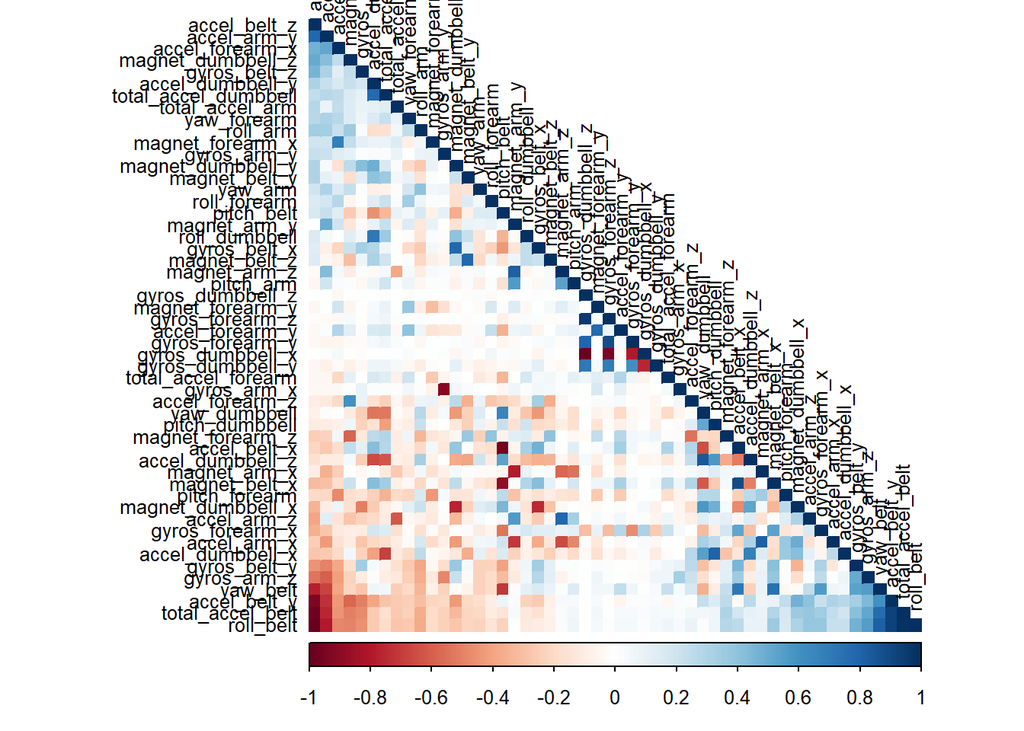

```r
corMatrix <- cor(training[, -53])
corrplot(corMatrix, order = "FPC", method = "color", type = "lower",
         tl.cex = 0.8, tl.col = rgb(0, 0, 0))
```

### Prediction Models

This section describes the medthods done for each model: the cross validation part, prediction using the testing dataset, and prediction using the testing classe, and the out of sample error value.

Sicne the Random Forest yielded the least out of sample error, random forest predictions were used in the quiz.

#### Random Forest

**Building the models**

```r
library(randomForest)
set.seed(7777)

rf.training=randomForest(classe~.,data=training,ntree=100, importance=TRUE)
rf.training
```

```
##
## Call:
##  randomForest(formula = classe ~ ., data = training, ntree = 100,      importance = TRUE)
##                Type of random forest: classification
##                      Number of trees: 100
## No. of variables tried at each split: 7
##
##         OOB estimate of  error rate: 0.82%
## Confusion matrix:
##      A    B    C    D    E  class.error
## A 3345    1    1    1    0 0.0008960573
## B   17 2255    7    0    0 0.0105309346
## C    0   19 2030    5    0 0.0116845180
## D    1    0   28 1896    5 0.0176165803
## E    0    1    4    6 2154 0.0050808314
```

**Cross validation**

```r
prediction <- predict(rf.training, testing, type = "class")
confusionMatrix(prediction, testing$classe)
```

```
## Confusion Matrix and Statistics
##
##           Reference
## Prediction    A    B    C    D    E
##          A 2229   11    0    0    0
##          B    0 1503   16    0    0
##          C    3    4 1351   17    0
##          D    0    0    1 1269    5
##          E    0    0    0    0 1437
##
## Overall Statistics
##
##                Accuracy : 0.9927
##                  95% CI : (0.9906, 0.9945)
##     No Information Rate : 0.2845
##     P-Value [Acc > NIR] : < 2.2e-16
##
##                   Kappa : 0.9908
##  Mcnemar's Test P-Value : NA
##
## Statistics by Class:
##
##                      Class: A Class: B Class: C Class: D Class: E
## Sensitivity            0.9987   0.9901   0.9876   0.9868   0.9965
## Specificity            0.9980   0.9975   0.9963   0.9991   1.0000
## Pos Pred Value         0.9951   0.9895   0.9825   0.9953   1.0000
## Neg Pred Value         0.9995   0.9976   0.9974   0.9974   0.9992
## Prevalence             0.2845   0.1935   0.1744   0.1639   0.1838
## Detection Rate         0.2841   0.1916   0.1722   0.1617   0.1832
## Detection Prevalence   0.2855   0.1936   0.1752   0.1625   0.1832
## Balanced Accuracy      0.9983   0.9938   0.9919   0.9929   0.9983
```

**Prediction**

```r
predictionRF <- predict(rf.training, ds_testing, type = "class")
predictionRF
```

```
##  1  2  3  4  5  6  7  8  9 10 11 12 13 14 15 16 17 18 19 20
##  B  A  B  A  A  E  D  B  A  A  B  C  B  A  E  E  A  B  B  B
## Levels: A B C D E
```

**Out of sample Error**

```r
out_of_sample_error <- 1 - postResample(prediction, testing$classe)[[1]]
out_of_sample_error
```

```
## [1] 0.007264848
```

#### Decision Tree MOdel

**Building the models**

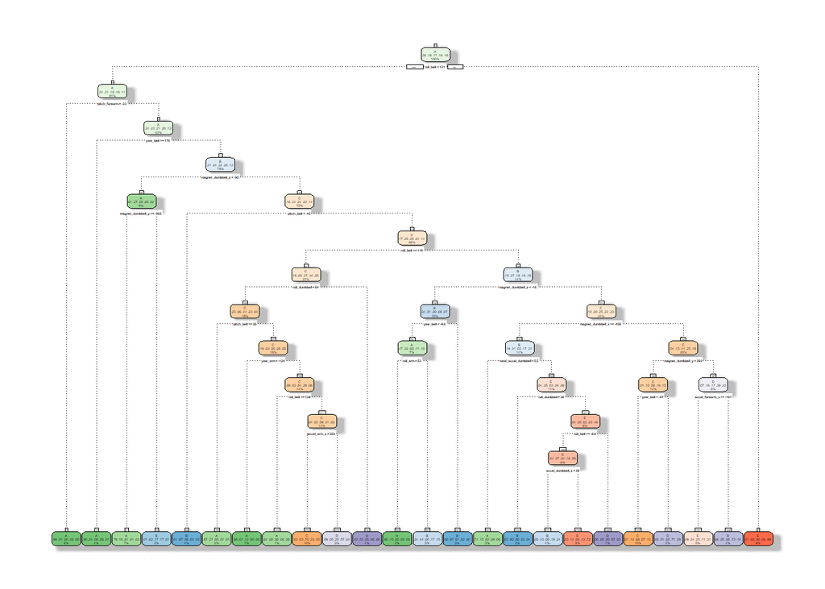

```r
dt.training<- rpart(classe ~ ., data = training, method="class")
fancyRpartPlot(dt.training, sub = "")
```

**Cross validation**

```r
set.seed(7777)

prediction <- predict(dt.training, testing, type = "class")
confusionMatrix(prediction, testing$classe)
```

```
## Confusion Matrix and Statistics
##
##           Reference
## Prediction    A    B    C    D    E
##          A 1973  262   35   45   52
##          B  116  992   95  208  166
##          C   42   96 1060  226  106
##          D   48   30   91  701  123
##          E   53  138   87  106  995
##
## Overall Statistics
##
##                Accuracy : 0.7292
##                  95% CI : (0.7192, 0.739)
##     No Information Rate : 0.2845
##     P-Value [Acc > NIR] : < 2.2e-16
##
##                   Kappa : 0.6564
##  Mcnemar's Test P-Value : < 2.2e-16
##
## Statistics by Class:
##
##                      Class: A Class: B Class: C Class: D Class: E
## Sensitivity            0.8840   0.6535   0.7749  0.54510   0.6900
## Specificity            0.9298   0.9076   0.9274  0.95549   0.9400
## Pos Pred Value         0.8335   0.6290   0.6928  0.70594   0.7215
## Neg Pred Value         0.9527   0.9161   0.9512  0.91464   0.9309
## Prevalence             0.2845   0.1935   0.1744  0.16391   0.1838
## Detection Rate         0.2515   0.1264   0.1351  0.08934   0.1268
## Detection Prevalence   0.3017   0.2010   0.1950  0.12656   0.1758
## Balanced Accuracy      0.9069   0.7805   0.8512  0.75029   0.8150
```

**Prediction**

```r
predictionDT <- predict(dt.training, ds_testing, type = "class")
predictionDT
```

```
##  1  2  3  4  5  6  7  8  9 10 11 12 13 14 15 16 17 18 19 20
##  A  A  E  A  A  C  D  D  A  A  B  E  B  A  E  E  A  B  A  B
## Levels: A B C D E
```

**Out of sample Error**

```r
out_of_sample_error <- 1 - postResample(prediction, testing$classe)[[1]]
out_of_sample_error
```

```
## [1] 0.2708386
```

#### Gradient Boosted Model

**Building the models**

```r
set.seed(12345)
controlGBM <- trainControl(method = "repeatedcv", number = 5, repeats = 1)
gb.training  <- train(classe ~ ., data=training, method = "gbm",
                    trControl = controlGBM, verbose = FALSE)
gb.training$finalModel
```

```
## A gradient boosted model with multinomial loss function.
## 150 iterations were performed.
## There were 52 predictors of which 43 had non-zero influence.
```

**Cross validation**

```r
#set.seed(12345)

prediction <- predict(gb.training, testing)
confusionMatrix(prediction, testing$classe)
```

```
## Confusion Matrix and Statistics
##
##           Reference
## Prediction    A    B    C    D    E
##          A 2198   53    0    2    3
##          B   21 1434   48    2   15
##          C    9   25 1310   55   11
##          D    2    3    8 1217   21
##          E    2    3    2   10 1392
##
## Overall Statistics
##
##                Accuracy : 0.9624
##                  95% CI : (0.958, 0.9665)
##     No Information Rate : 0.2845
##     P-Value [Acc > NIR] : < 2.2e-16
##
##                   Kappa : 0.9524
##  Mcnemar's Test P-Value : 9.493e-14
##
## Statistics by Class:
##
##                      Class: A Class: B Class: C Class: D Class: E
## Sensitivity            0.9848   0.9447   0.9576   0.9463   0.9653
## Specificity            0.9897   0.9864   0.9846   0.9948   0.9973
## Pos Pred Value         0.9743   0.9434   0.9291   0.9728   0.9879
## Neg Pred Value         0.9939   0.9867   0.9910   0.9895   0.9922
## Prevalence             0.2845   0.1935   0.1744   0.1639   0.1838
## Detection Rate         0.2801   0.1828   0.1670   0.1551   0.1774
## Detection Prevalence   0.2875   0.1937   0.1797   0.1594   0.1796
## Balanced Accuracy      0.9872   0.9655   0.9711   0.9706   0.9813
```

**Prediction**

```r
predictionGB <- predict(gb.training, ds_testing)
predictionGB
```

```
##  [1] B A B A A E D B A A B C B A E E A B B B
## Levels: A B C D E
```

**Out of sample error**

```r
out_of_sample_error <- 1 - postResample(prediction, testing$classe)[[1]]
out_of_sample_error
```

```
## [1] 0.03759878
```